# lightgbmvsxgboost

```r
# This R environment comes with many helpful analytics packages installed
# It is defined by the kaggle/rstats Docker image: https://github.com/kaggle/docker-rstats
# For example, here's a helpful package to load
library(tidyr)
library(dplyr)
library(ggplot2)
library(ggridges)
library(readr) #For reaading CSV Files
library(purrr)
library(corrplot)
library(caTools)
library(caret)
library(randomForest) #Used for Random Forest
library(ROSE)
library(rpart) #Used for Decision Tree
library(rpart.plot)
library(smotefamily) #Used for SMOTE
library(e1071) #Used for SVM
library(tidyverse) # metapackage with lots of helpful functions
#install.packages("lightgbm")
library(lightgbm) # loading LightGBM
library(pROC) # to use with AUC
library(RColorBrewer)#used for chart
library(scales) #used for chart
library(microbenchmark)
library(xgboost, quietly=TRUE)


# Input data files are available in the read-only "../input/" directory
# For example, running this (by clicking run or pressing Shift+Enter) will list all files under the input directory

#list.files(path = "../input/creditcard")

# You can write up to 5GB to the current directory (/kaggle/working/) that gets preserved as output when you create a version using "Save & Run All"
# You can also write temporary files to /kaggle/temp/, but they won't be saved outside of the current session
```

```r
credit.card.data = read.csv("../input/creditcardfraud/creditcard.csv")
```

```r
table(credit.card.data$Class)
```

```
     0      1
284315    492
```

Rescaling(Normalising) dataset

```r
library(reshape2) # melting tables

predictors <- select(credit.card.data, -Class) #Selecting whole data except class variable

rescale <- function(x) {
  return((x - min(x)) / (max(x) - min(x)))
}

predictors_rescaled <- as.data.frame(apply(predictors, 2, rescale)) #rescaling

cbind(melt(apply(predictors_rescaled, 2, min), value.name = "min_after_rescaling"),
      melt(apply(predictors_rescaled, 2, max), value.name = "max_after_rescaling"))
```

A data.frame: 30 × 2

|  | min_after_rescaling <dbl> | max_after_rescaling <dbl> |
| --- | --- | --- |
| Time | 0 | 1 |
| V1 | 0 | 1 |
| V2 | 0 | 1 |
| V3 | 0 | 1 |
| V4 | 0 | 1 |
| V5 | 0 | 1 |
| V6 | 0 | 1 |
| V7 | 0 | 1 |
| V8 | 0 | 1 |
| V9 | 0 | 1 |
| V10 | 0 | 1 |
| V11 | 0 | 1 |
| V12 | 0 | 1 |
| V13 | 0 | 1 |
| V14 | 0 | 1 |
| V15 | 0 | 1 |
| V16 | 0 | 1 |
| V17 | 0 | 1 |
| V18 | 0 | 1 |
| V19 | 0 | 1 |
| V20 | 0 | 1 |
| V21 | 0 | 1 |
| V22 | 0 | 1 |
| V23 | 0 | 1 |
| V24 | 0 | 1 |
| V25 | 0 | 1 |
| V26 | 0 | 1 |
| V27 | 0 | 1 |
| V28 | 0 | 1 |
| Amount | 0 | 1 |

```r
credit.card.data = cbind(credit.card.data$Class , predictors_rescaled)
```

```r
names(credit.card.data)[names(credit.card.data) == "credit.card.data$Class"] <- "Class"
head(credit.card.data)
```

A data.frame: 6 × 31

|  | Class <int> | Time <dbl> | V1 <dbl> | V2 <dbl> | V3 <dbl> | V4 <dbl> | V5 <dbl> | V6 <dbl> | V7 <dbl> | V8 <dbl> | ⋯ | V20 <dbl> | V21 <dbl> | V22 <dbl> | V23 <dbl> | V24 <dbl> | V25 <dbl> | V26 <dbl> | V27 <dbl> | V28 <dbl> | Amount <dbl> |
| --- | --- | --- | --- | --- | --- | --- | --- | --- | --- | --- | --- | --- | --- | --- | --- | --- | --- | --- | --- | --- | --- |
| 1 | 0 | 0.000000e+00 | 0.9351923 | 0.7664904 | 0.8813649 | 0.3130227 | 0.7634387 | 0.2676686 | 0.2668152 | 0.7864442 | ⋯ | 0.5829422 | 0.5611844 | 0.5229921 | 0.6637930 | 0.3912527 | 0.5851218 | 0.3945568 | 0.4189761 | 0.3126966 | 0.0058237931 |
| 2 | 0 | 0.000000e+00 | 0.9785420 | 0.7700667 | 0.8402985 | 0.2717965 | 0.7661203 | 0.2621917 | 0.2648754 | 0.7862984 | ⋯ | 0.5795298 | 0.5578399 | 0.4802370 | 0.6669378 | 0.3364400 | 0.5872903 | 0.4460130 | 0.4163451 | 0.3134227 | 0.0001047053 |
| 3 | 0 | 5.787305e-06 | 0.9352170 | 0.7531177 | 0.8681408 | 0.2687655 | 0.7623288 | 0.2811221 | 0.2701772 | 0.7880423 | ⋯ | 0.5858550 | 0.5654773 | 0.5460298 | 0.6789392 | 0.2893539 | 0.5595152 | 0.4027272 | 0.4154893 | 0.3119113 | 0.0147389219 |
| 4 | 0 | 5.787305e-06 | 0.9418780 | 0.7653040 | 0.8684836 | 0.2136612 | 0.7656469 | 0.2755592 | 0.2668031 | 0.7894342 | ⋯ | 0.5780502 | 0.5597337 | 0.5102770 | 0.6626072 | 0.2238259 | 0.6142454 | 0.3891967 | 0.4176687 | 0.3143710 | 0.0048071010 |
| 5 | 0 | 1.157461e-05 | 0.9386168 | 0.7765198 | 0.8642507 | 0.2697964 | 0.7629751 | 0.2639842 | 0.2689678 | 0.7824835 | ⋯ | 0.5846153 | 0.5613275 | 0.5472707 | 0.6633922 | 0.4012698 | 0.5663427 | 0.5074968 | 0.4205610 | 0.3174900 | 0.0027242834 |
| 6 | 0 | 1.157461e-05 | 0.9510571 | 0.7773933 | 0.8571874 | 0.2444717 | 0.7685504 | 0.2627209 | 0.2682566 | 0.7881778 | ⋯ | 0.5811700 | 0.5581224 | 0.4839152 | 0.6650416 | 0.3321846 | 0.5648393 | 0.4427493 | 0.4211963 | 0.3147692 | 0.0001428507 |

Train/Test Split

```r
set.seed(123)
train.test.split1 <- sample(2
	, nrow(credit.card.data)
	, replace = TRUE
	, prob = c(0.7, 0.3))
train = credit.card.data[train.test.split1 == 1,]
test = credit.card.data[train.test.split1 == 2,]
```

```r
head(train)
```

A data.frame: 6 × 31

|  | Class <int> | Time <dbl> | V1 <dbl> | V2 <dbl> | V3 <dbl> | V4 <dbl> | V5 <dbl> | V6 <dbl> | V7 <dbl> | V8 <dbl> | ⋯ | V20 <dbl> | V21 <dbl> | V22 <dbl> | V23 <dbl> | V24 <dbl> | V25 <dbl> | V26 <dbl> | V27 <dbl> | V28 <dbl> | Amount <dbl> |
| --- | --- | --- | --- | --- | --- | --- | --- | --- | --- | --- | --- | --- | --- | --- | --- | --- | --- | --- | --- | --- | --- |
| 1 | 0 | 0.000000e+00 | 0.9351923 | 0.7664904 | 0.8813649 | 0.3130227 | 0.7634387 | 0.2676686 | 0.2668152 | 0.7864442 | ⋯ | 0.5829422 | 0.5611844 | 0.5229921 | 0.6637930 | 0.3912527 | 0.5851218 | 0.3945568 | 0.4189761 | 0.3126966 | 0.0058237931 |
| 3 | 0 | 5.787305e-06 | 0.9352170 | 0.7531177 | 0.8681408 | 0.2687655 | 0.7623288 | 0.2811221 | 0.2701772 | 0.7880423 | ⋯ | 0.5858550 | 0.5654773 | 0.5460298 | 0.6789392 | 0.2893539 | 0.5595152 | 0.4027272 | 0.4154893 | 0.3119113 | 0.0147389219 |
| 6 | 0 | 1.157461e-05 | 0.9510571 | 0.7773933 | 0.8571874 | 0.2444717 | 0.7685504 | 0.2627209 | 0.2682566 | 0.7881778 | ⋯ | 0.5811700 | 0.5581224 | 0.4839152 | 0.6650416 | 0.3321846 | 0.5648393 | 0.4427493 | 0.4211963 | 0.3147692 | 0.0001428507 |
| 7 | 0 | 2.314922e-05 | 0.9791841 | 0.7687462 | 0.8381998 | 0.3052410 | 0.7670080 | 0.2657616 | 0.2653241 | 0.7862566 | ⋯ | 0.5779268 | 0.5587758 | 0.4974024 | 0.6631450 | 0.2771220 | 0.6200136 | 0.3834292 | 0.4171479 | 0.3132287 | 0.0001942302 |
| 9 | 0 | 4.051113e-05 | 0.9431010 | 0.7702777 | 0.8354522 | 0.2398937 | 0.7836880 | 0.3004392 | 0.2676105 | 0.7945149 | ⋯ | 0.5808268 | 0.5602959 | 0.4975245 | 0.6624006 | 0.5185457 | 0.5988555 | 0.3626970 | 0.4167278 | 0.3160137 | 0.0036277070 |
| 10 | 0 | 5.208574e-05 | 0.9525471 | 0.7790717 | 0.8555110 | 0.2420808 | 0.7690780 | 0.2605388 | 0.2693250 | 0.7861314 | ⋯ | 0.5824343 | 0.5574992 | 0.4804664 | 0.6636397 | 0.3303489 | 0.5739923 | 0.4408355 | 0.4210556 | 0.3148097 | 0.0001432399 |

# Modeling

We have attempted to select a common set of parameters for each model, but that is not entirely possible. (max_depth vs num_leaves in xgboost and lightGBM) The following are some of the assumptions and choices made during this modeling process.

The data will be placed into the their preferred data formats before calling the models. Previously we have seen how do we do cross validation(3 fold) for XGBoost, but it is taking too much time to train(2hrs). So we decided not to build model that are not to be trained with cross-validation.

```r
lgb.train = lgb.Dataset(as.matrix(train[, colnames(train) != "Class"]), label = train$Class)
lgb.test = lgb.Dataset(as.matrix(test[, colnames(test) != "Class"]), label = test$Class)
```

```r
params.lgb = list(
	objective = "binary"
	, metric = "auc"
	, min_data_in_leaf = 1
	, min_sum_hessian_in_leaf = 100
	, feature_fraction = 1
	, bagging_fraction = 1
	, bagging_freq = 0
	)

# Get the time to train the lightGBM model

lgb.model <- lgb.train(
    params = params.lgb
    , data = lgb.train
    , valids = list(test = lgb.test)
    , learning_rate = 0.1
    , num_leaves = 7
    , num_threads = 2
    , nrounds = 500
    , early_stopping_rounds = 30
    , eval_freq = 20
    )
```

```
[1]:	test's auc:0.82843
[21]:	test's auc:0.971265
[41]:	test's auc:0.971027
```

```
Call:
roc.default(response = test$Class, predictor = lgb.test, plot = TRUE,     col = "green")

Data: lgb.test in 85419 controls (test$Class 0) < 148 cases (test$Class 1).
Area under the curve: 0.9723
```

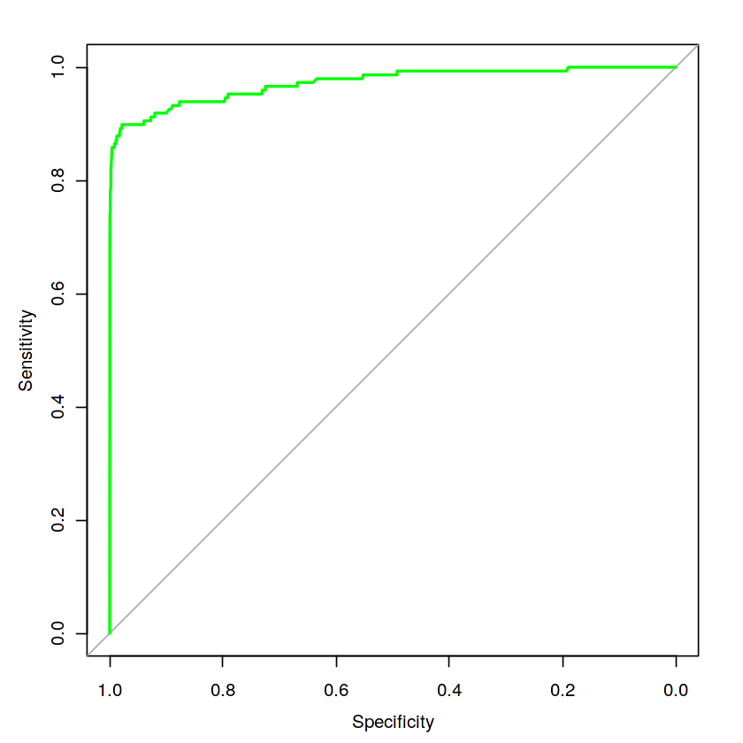

```r
#print(max(unlist(lgb.model1$record_evals[["test"]][["auc"]][["eval"]])))

# get feature importance
lgb.feature.imp = lgb.importance(lgb.model, percentage = TRUE)

# make test predictions
lgb.test = predict(lgb.model, data = as.matrix(test[, colnames(test) != "Class"]), n = lgb.model$best_iter)
auc.lgb = roc(test$Class, lgb.test, plot = TRUE, col = "green")
print(auc.lgb)
```

Important Variables that are valuable for this model

```r
print(lgb.feature.imp)
```

```
   Feature         Gain      Cover  Frequency
1:     V14 0.4042556392 0.24934430 0.23913043
2:      V4 0.1805369122 0.37377274 0.39130435
3:     V12 0.1780205404 0.19555016 0.19565217
4:     V10 0.1174900481 0.07137271 0.06521739
5:     V11 0.0839025545 0.04758181 0.04347826
6:     V16 0.0351637475 0.02379090 0.02173913
7:     V19 0.0003203109 0.01713557 0.02173913
8:      V1 0.0003102473 0.02145182 0.02173913
```

```r
n0 = 284315
n1 = 492
r0 = 0.65
ntimes = ((1-r0) / r0) * (n0/n1) - 1
print(ntimes)
```

```
[1] 310.164
```

```r
set.seed(1234)

smote_output = SMOTE(X = credit.card.data[,-c(1,31)],target = credit.card.data$Class,K=5,dup_size = ntimes)

credit_smote = smote_output$data

colnames(credit_smote)[30] <- "Class"
```

```r
set.seed(123)
train.test.split <- sample(2
	, nrow(credit_smote)
	, replace = TRUE
	, prob = c(0.7, 0.3))
smote_train = credit_smote[train.test.split == 1,]
smote_test = credit_smote[train.test.split == 2,]
```

```r
smote_lgb.train = lgb.Dataset(as.matrix(smote_train[, colnames(smote_train) != "Class"]), label = smote_train$Class)
smote_lgb.test = lgb.Dataset(as.matrix(smote_test[, colnames(smote_test) != "Class"]), label = smote_test$Class)
```

```r
smote_params.lgb = list(
	objective = "binary"
	, metric = "auc"
	, min_data_in_leaf = 30
	, min_sum_hessian_in_leaf = 100
	, feature_fraction = .9
	, bagging_fraction = 1
	, bagging_freq = 0
    , lambda_l1 =   8
    , lambda_l2 = 1.4
    , min_gain_to_split = 15
    , num_best_round = 30000
	)

# Get the time to train the lightGBM model

smote.lgb.model <- lgb.train(
    params = smote_params.lgb
    , data = smote_lgb.train
    , valids = list(test = smote_lgb.test)
    , learning_rate = 0.1
    , num_leaves = 7
    , num_threads = 2
    , nrounds = 500
    , early_stopping_rounds = 30
    , eval_freq = 20
    )
```

```
[1]:	test's auc:0.942466
[21]:	test's auc:0.991261
[41]:	test's auc:0.995943
[61]:	test's auc:0.997657
[81]:	test's auc:0.998616
[101]:	test's auc:0.999074
[121]:	test's auc:0.999347
[141]:	test's auc:0.999505
[161]:	test's auc:0.999604
[181]:	test's auc:0.999677
[201]:	test's auc:0.999725
[221]:	test's auc:0.999767
[241]:	test's auc:0.999794
[261]:	test's auc:0.999794
```

```
Call:
roc.default(response = smote_test$Class, predictor = smote_lgb.test,     plot = TRUE, col = "green")

Data: smote_lgb.test in 85440 controls (smote_test$Class 0) < 45995 cases (smote_test$Class 1).
Area under the curve: 0.9998
```

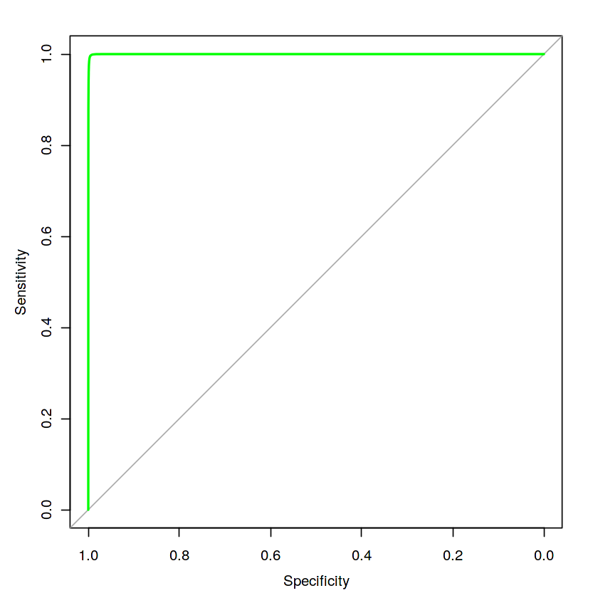

```r
#print(max(unlist(lgb.model1$record_evals[["test"]][["auc"]][["eval"]])))

# get feature importance
smote_lgb.feature.imp = lgb.importance(smote.lgb.model, percentage = TRUE)

# make test predictions
smote_lgb.test = predict(smote.lgb.model, data = as.matrix(smote_test[, colnames(smote_test) != "Class"]), n = smote.lgb.model$best_iter)
smote_auc.lgb = roc(smote_test$Class, smote_lgb.test, plot = TRUE, col = "green")
print(smote_auc.lgb)
```

Important Variables that are valuable for this model

```r
print(smote_lgb.feature.imp)
```

```
    Feature        Gain       Cover  Frequency
 1:     V14 0.486282710 0.098093905 0.07782369
 2:     V10 0.231956640 0.025330002 0.02410468
 3:      V4 0.061646391 0.076257803 0.07300275
 4:     V12 0.037251416 0.044125052 0.03994490
 5:     V17 0.024554971 0.035802966 0.03168044
 6:      V8 0.023954090 0.046791181 0.05027548
 7:      V1 0.015238063 0.068241150 0.05785124
 8:      V3 0.012343291 0.047650919 0.05234160
 9:      V2 0.011991259 0.033531848 0.04201102
10:     V18 0.010076825 0.049483653 0.04338843
11:     V19 0.008538937 0.028043869 0.02823691
12:     V11 0.008317830 0.031496205 0.03030303
13:    Time 0.006872618 0.035365122 0.04338843
14:     V13 0.006864848 0.018160889 0.02685950
```

[output cut: 16 more lines]

```
Will train until test_auc hasn't improved in 40 rounds.

Stopping. Best iteration:

NULL
```

```
Call:
roc.default(response = test$Class, predictor = xgb.test.speed,     plot = TRUE, col = "blue")

Data: xgb.test.speed in 85419 controls (test$Class 0) < 148 cases (test$Class 1).
Area under the curve: 0.9708
```

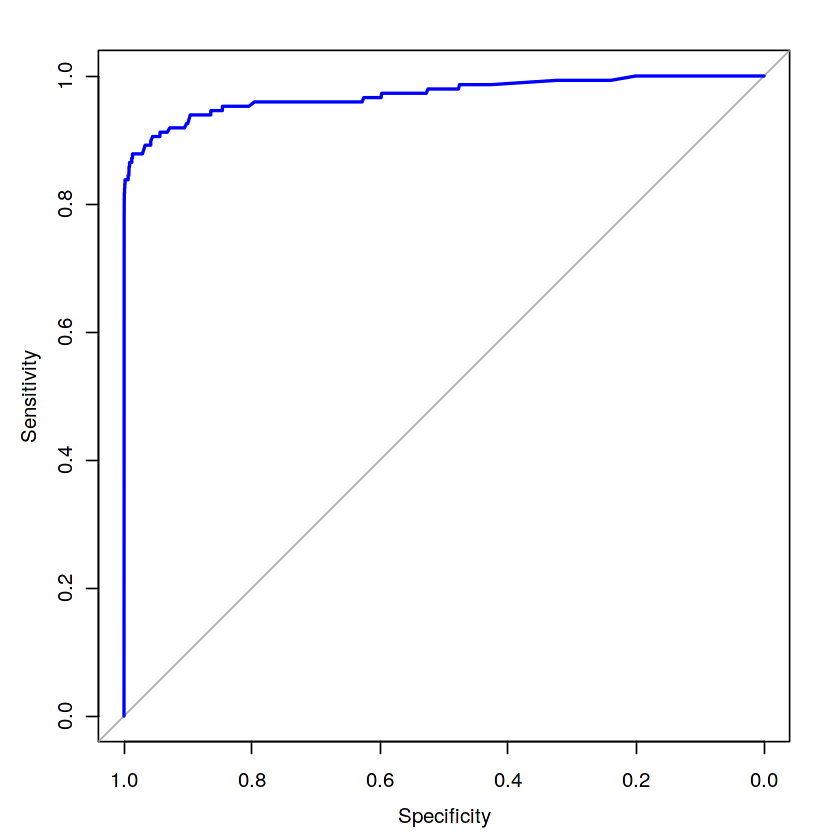

```r
library(xgboost, quietly=TRUE)
xgb.data.train <- xgb.DMatrix(as.matrix(train[, colnames(train) != "Class"]), label = train$Class)
xgb.data.test <- xgb.DMatrix(as.matrix(test[, colnames(test) != "Class"]), label = test$Class)

# Get the time to train the xgboost model

xgb.model.speed <- xgb.train(data = xgb.data.train
    , params = list(objective = "binary:logistic"
        , eta = 0.1
        , max.depth = 3
        , min_child_weight = 100
        , subsample = 1
        , colsample_bytree = 1
        , nthread = 3
        , eval_metric = "auc"
        )
    , watchlist = list(test = xgb.data.test)
    , nrounds = 500
    , early_stopping_rounds = 40
    , print_every_n = 20
    )

print(xgb.model.speed$bestScore)

# Make predictions on test set for ROC curve
xgb.test.speed = predict(xgb.model.speed
                   , newdata = as.matrix(test[, colnames(test) != "Class"])
                   , ntreelimit = xgb.model.speed$bestInd)
auc.xgb.speed = roc(test$Class, xgb.test.speed, plot = TRUE, col = "blue")
print(auc.xgb.speed)
```

```
Will train until test_auc hasn't improved in 40 rounds.

NULL
```

```
Call:
roc.default(response = smote_test$Class, predictor = smote_xgb.test.speed,     plot = TRUE, col = "blue")

Data: smote_xgb.test.speed in 85440 controls (smote_test$Class 0) < 45995 cases (smote_test$Class 1).
Area under the curve: 0.9999
```

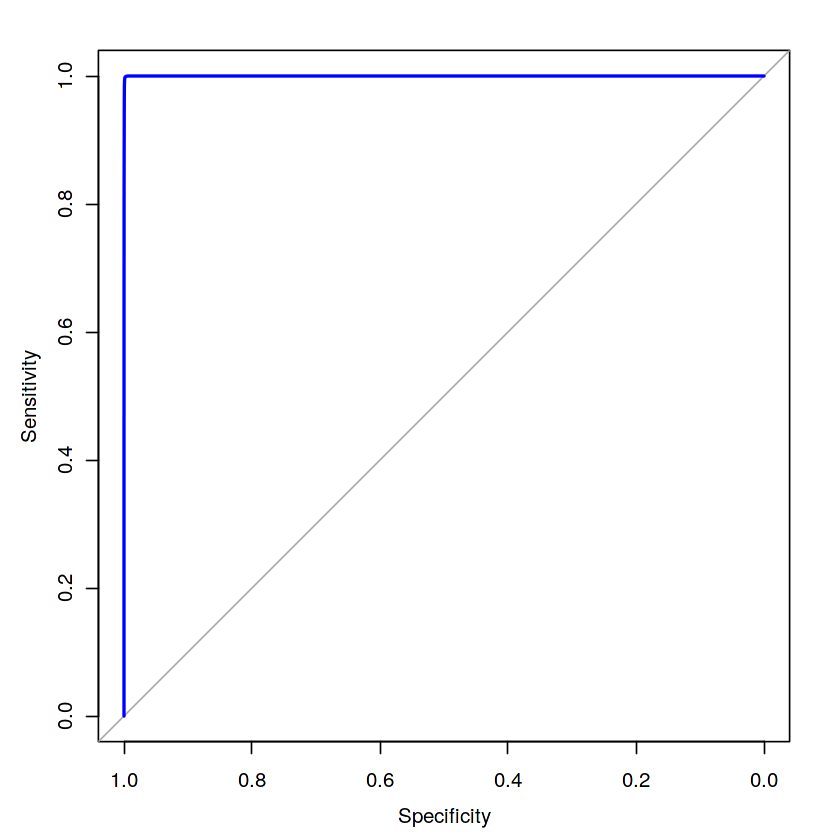

```r
smote_xgb.data.train <- xgb.DMatrix(as.matrix(smote_train[, colnames(smote_train) != "Class"]), label = smote_train$Class)
smote_xgb.data.test <- xgb.DMatrix(as.matrix(smote_test[, colnames(smote_test) != "Class"]), label = smote_test$Class)

# Get the time to train the xgboost model

smote_xgb.model.speed <- xgb.train(data = smote_xgb.data.train
    , params = list(objective = "binary:logistic"
        , eta = 0.1
        , max.depth = 3
        , min_child_weight = 100
        , subsample = 1
        , colsample_bytree = 1
        , nthread = 3
        , eval_metric = "auc"
        )
    , watchlist = list(test = smote_xgb.data.test)
    , nrounds = 500
    , early_stopping_rounds = 40
    , print_every_n = 20
    )

print(smote_xgb.model.speed$bestScore)

# Make predictions on test set for ROC curve
smote_xgb.test.speed = predict(smote_xgb.model.speed
                   , newdata = as.matrix(smote_test[, colnames(smote_test) != "Class"])
                   , ntreelimit = smote_xgb.model.speed$bestInd)
smote_auc.xgb.speed = roc(smote_test$Class, smote_xgb.test.speed, plot = TRUE, col = "blue")
print(smote_auc.xgb.speed)
```

# lightGBM

**Advantages**:

- Fast training efficiency
- Low memory usage
- Better accuracy
- Parallel learning supported
- Deal with large scale data

**Disadvantages**:

- Newer, so less community documentation